# Homework 1

Jenny St. Clair

# Watch this for a tour of R Markdown: https://www.youtube.com/watch?v=DNS7i2m4sB0

## Run this code chunk first.

```r
library(tidyverse)
library(lubridate)
library(plotly)
```

## Read in and prep data.

Data source: https://www.airnowtech.org/

```r
data <- read.csv("MD_o3_1029_tidy.csv")

data <- data %>% select (-c(X,time))

data$Site.AQS.split <- as.character(data$Site.AQS)
data<- data %>% separate(Site.AQS.split, c("State.FIPS", "County.AQS"), 2)
data <- data %>% separate(County.AQS, c("County.FIPS", "Site"), 3)

data$Site.AQS <- as.factor(data$Site.AQS)
data$State.FIPS <- as.factor(data$State.FIPS)
data$County.FIPS <- as.factor(data$County.FIPS)
data$Method <- as.factor(data$Method)

data <- data %>% filter(State.FIPS == "24")


data$date <- data$date %>%
  as_datetime()

str(data)
```

```
## 'data.frame':    724 obs. of  8 variables:
##  $ o3         : int  30 31 33 33 32 29 29 29 33 36 ...
##  $ Agency     : Factor w/ 5 levels "MD1","NJ1","NY1",..: 1 1 1 1 1 1 1 1 1 1 ...
##  $ Site.AQS   : Factor w/ 68 levels "240031003","240051007",..: 13 13 13 13 13 13 13 13 13 13 ...
##  $ Method     : Factor w/ 2 levels "47","87": 1 1 1 1 1 1 1 1 1 1 ...
##  $ date       : POSIXct, format: "2019-10-28 00:00:00" "2019-10-28 01:00:00" ...
##  $ State.FIPS : Factor w/ 3 levels "24","34","36": 1 1 1 1 1 1 1 1 1 1 ...
##  $ County.FIPS: Factor w/ 37 levels "001","003","005",..: 13 13 13 13 13 13 13 13 13 13 ...
##  $ Site       : chr  "9001" "9001" "9001" "9001" ...
```

# Homework 1

### 1. This script works on the Iris dataset that comes with R. You should be able to run it as is just fine.

### 2. Change it to use the same data we used here. The data prep is included above.

### 3. Let the histogram show the frequency of different ozone values in the dataset (ozone on the x-axis, no y-axis variable necessary).

### 4. Change the number of bins (in geom_histogram()) to 20, then try 40.

### 5. Use the labs() function to add a title, a subtitle with your name, and rename the x-axis “Ozone.”

### 6. I will email the solution to this homework next week, though we will not have time to cover it in Webinar 2.

# For fun:

### 1. Try applying different themes to your plot.

https://www.datanovia.com/en/blog/ggplot-themes-gallery/

### 2. Use the function plotly::ggplotly() to make the graphic interactive.

https://plot.ly/ggplot2/

### 3. See what happens if you put <fill = Site.AQS> in the aes() function inside geom_histogram().

Remember, when you run into errors and weird results, don’t spend too much time thinking about it. If you can’t think of a solution after a couple minutes, google it! StackExchange/StackOverflow is your friend too. If the internet isn’t helping, shoot me an email or give me a call.

https://ggplot2.tidyverse.org/reference/geom_histogram.html

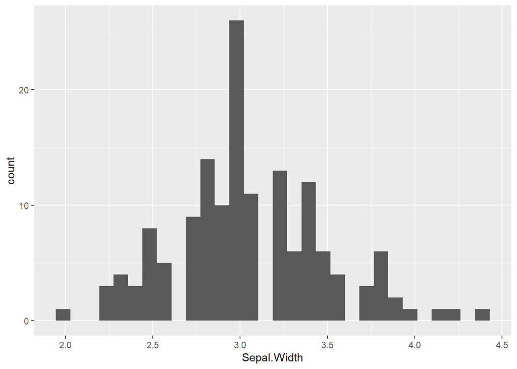

```r
plot <- iris %>%
  ggplot(aes(Sepal.Width)) +
  geom_histogram(bins = 30)

plot
```